# Hand in Ice Bucket Experiment: Statistical Analysis & Report Summary

**Question:** Is there a statistically significant difference between the amount of time people put their hand across the two groups?

- In one group A, participants are told that the average time people hold their hand in the water is 15 seconds, and the record is 1 minute 30 seconds.
- In another group B, participants are told that the average time people hold their hand in the water is 30 seconds and the record is 2 minutes.

### Sampling Procedure and Summary:

Participants were randomly assigned among the two groups. Participants were randomly sampled from Kerry Park, meaning the data is likely representative of a combination of an upper-class population from Queen Anne and tourists. There was potential participation bias, which might be influence the generalization of the study, but was not a counfounding variable. However, the social nature of informal experiment might have created a confounding variable; people would often go one after another, witnessing each other and exhibiting a competitive mindset, meaning one's result sometimes affected the next. This was difficult to control for because the social aspect of the experiment was a driving motive for participation.

### Resulting Assumptions for Statistical Analysis

Because of the small sample size, limited gaussian properties of the distribution, and strong outliers (due to both small sample size and variance in presentation circumstances), we utilized a non-parametric test to test across the two groups. This was a Mann-Whitney U-test, the non-parametric alternative for a 2-sample independent t-test.

### Hypotheses:

H_0: There is no significant difference between the groups; stated average and record does not influence time hand is held in ice bucket.

H_A: There is a significant difference between the groups; stated average and record does influence time hand is held in ice bucket.

# Setup

```r
# Load necessary library
library(dplyr)
library(tidyr)
library(ggplot2)

# Load data.csv
data <- read.csv("data.csv")
# Check the structure of the data
str(data)
```

```
'data.frame':	14 obs. of  2 variables:
 $ Mean15SecondsRecordOneThirty : num  30 142 40 92 15 16 35 91 5 45 ...
 $ Mean30SecondsRecordTwoMinutes: num  31.6 42.5 120 150 31 75 60 61 15 60.2 ...
```

```r
# Convert from wide to long format
# columns a and b go into one column and another column represents if its a or b

data_long <- data %>%
  pivot_longer(cols = c(Mean15SecondsRecordOneThirty, Mean30SecondsRecordTwoMinutes),
               names_to = "variable",
               values_to = "value")
```

# Exploratory Data Analysis

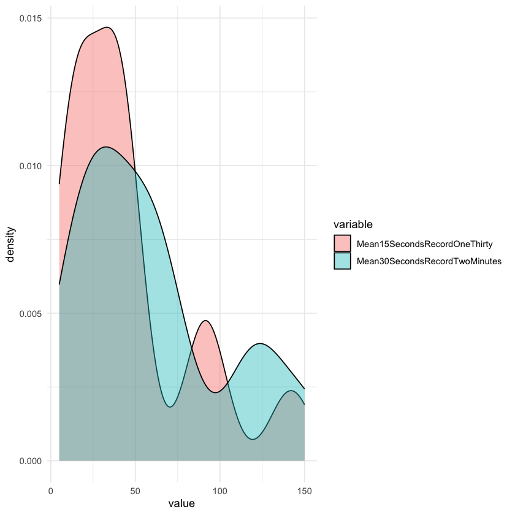

```r
# EDA using kernel plot of vars a and b in different colors on same graph

ggplot(data_long, aes(x = value,  fill = variable)) +
  geom_density(alpha = 0.4) +
  theme_minimal()
```

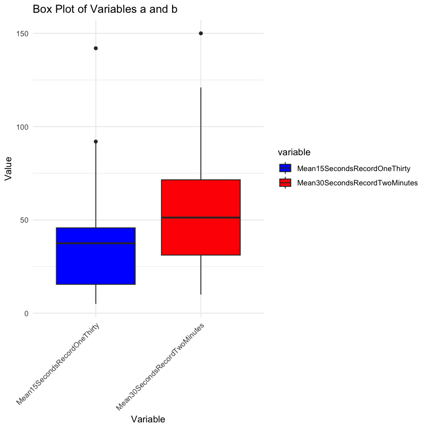

```r
# Box plot
ggplot(data_long, aes(x = variable, y = value, fill = variable)) +
  geom_boxplot() +
  theme_minimal() +
  theme(axis.text.x = element_text(angle = 45, hjust = 1)) +
  labs(x = "Variable", y = "Value", title = "Box Plot of Variables a and b") +
  scale_fill_manual(values = c("Mean15SecondsRecordOneThirty" = "blue",
                                "Mean30SecondsRecordTwoMinutes" = "red"))
```

# Test and Results

```r
# Perform the Mann-Whitney U test
result <- wilcox.test(data$Mean15SecondsRecordOneThirty, data$Mean30SecondsRecordTwoMinutes, alternative = "two.sided")
print(result)
```

```
	Wilcoxon rank sum test with continuity correction

data:  data$Mean15SecondsRecordOneThirty and data$Mean30SecondsRecordTwoMinutes
W = 79, p-value = 0.3952
alternative hypothesis: true location shift is not equal to 0
```

# Results

Even though the data appears to have a trend, it not statistically signficant with a p-value of 0.39, so we must accept the null hypothesis. It is possible this is due to small sample size and inconsistencies outlined above. In order to improve this experiment, it might be beneficial to take more samples and isolate participants from each other, even though it would make it much more difficult to find people willing to participate. For now, however, we determine that there is not a significant influence of how much time we told participants was the average and record times that a hand was held in the ice bucket on the amount of time participants did so.